# Introduction

Categorical Feature Encoding Challenge: Kaggle Link

In this project the data file have lots of categorical features. We are asked to predict a binay target based on other features using various techniques of feature encodings.

# Data Description

```
# id features
'id',

# binary features
'bin_0', 'bin_1', 'bin_2', 'bin_3', 'bin_4',

# nominal features
'nom_0', 'nom_1','nom_2', 'nom_3', 'nom_4',
'nom_5', 'nom_6', 'nom_7', 'nom_8', 'nom_9',

# ordinal features
'ord_0', 'ord_1', 'ord_2', 'ord_3', 'ord_4', 'ord_5',

# cyclical features
 'day', 'month',

# binary target
'target'
```

# Types of Data

- **Continuous Data**
  - Numbers like 0.0, 0.1, ..., 100.0 etc are continuous data.
  - We can use histogram binnings to encode continuous data.
  - We can groupby features and use various statistics such as mean, max etc.
- **Categorical Data**
  - **Binary data** : Binary data has two values,e.g. 0/1, -1/1, True/False
  - **Categorical data** : Has few limited variables. E.g. 1-7 for weekdays.
  - **Ordinal data** : Has order in it. Eg. Movie review Bad,medium,Good.
  - **Nominal data** : Nominal values without order. E.g. USA,Nepal,Canada
- **Timeseries data** : These can be continuous and discrete. They have time associated with them. When using train-test split we should not shuffle them.

# Resources

- [Cyclical Features](https://ianlondon.github.io/blog/encoding-cyclical-features-24hour-time/)
- [An Overview of Encoding Techniques](https://www.kaggle.com/shahules/an-overview-of-encoding-techniques)
- [Cat in dat: OHE vs Thermometer + Logit](https://www.kaggle.com/pavelvpster/cat-in-dat-ohe-vs-thermometer-logit)

# Imports

```python
import numpy as np
import pandas as pd
import seaborn as sns
sns.set(color_codes=True)

import matplotlib
import matplotlib.pyplot as plt
%matplotlib inline
%config InlineBackend.figure_format = 'retina'
sns.set(context='notebook', style='whitegrid', rc={'figure.figsize': (12,8)})
plt.style.use('ggplot') # better than sns styles.
matplotlib.rcParams['figure.figsize'] = 12,8

import os
import time

# random state
SEED=100
np.random.seed(SEED)

# Jupyter notebook settings for pandas
#pd.set_option('display.float_format', '{:,.2g}'.format) # numbers sep by comma
pd.options.display.float_format = '{:,}'.format # df.A.value_counts().astype(float)
from pandas.api.types import CategoricalDtype
np.set_printoptions(precision=3)

pd.set_option('display.max_columns', 100)
pd.set_option('display.max_rows', 100) # None for all the rows
pd.set_option('display.max_colwidth', 200)

import IPython
from IPython.display import display, HTML, Image, Markdown

print([(x.__name__,x.__version__) for x in [np, pd,sns,matplotlib]])
```

```
[('numpy', '1.17.4'), ('pandas', '0.25.3'), ('seaborn', '0.9.0'), ('matplotlib', '3.1.2')]
```

```python
ENV_BHISHAN = None

try:
    import bhishan
    ENV_BHISHAN = True
    print("Environment: Bhishan's Laptop")
except:
    pass


import sys
ENV_COLAB = 'google.colab' in sys.modules

if ENV_COLAB:
    # load google drive
    # from google.colab import drive
    # drive.mount('/content/drive')
    # dat_dir = 'drive/My Drive/Colab Notebooks/data/'
    # sys.path.append(dat_dir)

    # pip install
    #!pip install pyldavis
    # !pip install hyperopt
    # !pip install catboost
    #!pip install shap
    #!pip install eli5
    #!pip install lime
    # !pip install category_encoders # TargetEncoder
    # !pip install optuna # hyper param opt

    # print
    print('Environment: Google Colaboratory.')

if ENV_COLAB:
    # update modules
    # !pip install -U scikit-learn
    # !pip install -U tqdm # tqdm needs restart run time.
    pass
```

```
Environment: Google Colaboratory.
```

# Load the Data

```python
ifile = 'https://github.com/bhishanpdl/Project_Categorical_Feature_Encoding/blob/master/data/raw/train.csv?raw=true'
df = pd.read_csv(ifile)
df.drop('id', axis=1, inplace=True)
print(df.shape)
df.head()
```

```
(300000, 24)
```

|  | bin_0 | bin_1 | bin_2 | bin_3 | bin_4 | nom_0 | nom_1 | nom_2 | nom_3 | nom_4 | nom_5 | nom_6 | nom_7 | nom_8 | nom_9 | ord_0 | ord_1 | ord_2 | ord_3 | ord_4 | ord_5 | day | month | target |
| --- | --- | --- | --- | --- | --- | --- | --- | --- | --- | --- | --- | --- | --- | --- | --- | --- | --- | --- | --- | --- | --- | --- | --- | --- |
| 0 | 0 | 0 | 0 | T | Y | Green | Triangle | Snake | Finland | Bassoon | 50f116bcf | 3ac1b8814 | 68f6ad3e9 | c389000ab | 2f4cb3d51 | 2 | Grandmaster | Cold | h | D | kr | 2 | 2 | 0 |
| 1 | 0 | 1 | 0 | T | Y | Green | Trapezoid | Hamster | Russia | Piano | b3b4d25d0 | fbcb50fc1 | 3b6dd5612 | 4cd920251 | f83c56c21 | 1 | Grandmaster | Hot | a | A | bF | 7 | 8 | 0 |
| 2 | 0 | 0 | 0 | F | Y | Blue | Trapezoid | Lion | Russia | Theremin | 3263bdce5 | 0922e3cb8 | a6a36f527 | de9c9f684 | ae6800dd0 | 1 | Expert | Lava Hot | h | R | Jc | 7 | 2 | 0 |
| 3 | 0 | 1 | 0 | F | Y | Red | Trapezoid | Snake | Canada | Oboe | f12246592 | 50d7ad46a | ec69236eb | 4ade6ab69 | 8270f0d71 | 1 | Grandmaster | Boiling Hot | i | D | kW | 2 | 1 | 1 |
| 4 | 0 | 0 | 0 | F | N | Red | Trapezoid | Lion | Canada | Oboe | 5b0f5acd5 | 1fe17a1fd | 04ddac2be | cb43ab175 | b164b72a7 | 1 | Grandmaster | Freezing | a | R | qP | 7 | 8 | 0 |

# Useful Codes

```python
def show_method_attributes(obj, ncols=7,start=None, inside=None):
    """ Show all the attributes of a given method.
    Example:
    ========
    show_method_attributes(list)
     """

    print(f'Object Type: {type(obj)}\n')
    lst = [elem for elem in dir(obj) if elem[0]!='_' ]
    lst = [elem for elem in lst
           if elem not in 'os np pd sys time psycopg2'.split() ]

    if isinstance(start,str):
        lst = [elem for elem in lst if elem.startswith(start)]

    if isinstance(start,tuple) or isinstance(start,list):
        lst = [elem for elem in lst for start_elem in start
               if elem.startswith(start_elem)]

    if isinstance(inside,str):
        lst = [elem for elem in lst if inside in elem]

    if isinstance(inside,tuple) or isinstance(inside,list):
        lst = [elem for elem in lst for inside_elem in inside
               if inside_elem in elem]

    return pd.DataFrame(np.array_split(lst,ncols)).T.fillna('')
```

```python
def summarize(df):
    summary = pd.DataFrame(df.dtypes,columns=['dtypes'])
    summary = summary.reset_index()
    summary['Name'] = summary['index']
    summary = summary[['Name','dtypes']]
    summary['Missing'] = df.isnull().sum().values
    summary['Uniques'] = df.nunique().values
    summary['First Value'] = df.iloc[0].values
    summary['Second Value'] = df.iloc[1].values
    summary['Second Last Value'] = df.iloc[-2].values
    summary['Last Value'] = df.iloc[-1].values
    return summary
```

```python
def reduce_mem_usage(df):
    """ Reduce the memory of pandas dataframe.
    """
    start_mem = df.memory_usage().sum() / 1024**2
    print('Memory usage of dataframe is {:.2f} MB'.format(start_mem))

    for col in df.columns:
        col_type = df[col].dtype

        if col_type != object:
            c_min = df[col].min()
            c_max = df[col].max()
            if str(col_type)[:3] == 'int':
                if c_min > np.iinfo(np.int8).min and c_max < np.iinfo(np.int8).max:
                    df[col] = df[col].astype(np.int8)
                elif c_min > np.iinfo(np.int16).min and c_max < np.iinfo(np.int16).max:
                    df[col] = df[col].astype(np.int16)
                elif c_min > np.iinfo(np.int32).min and c_max < np.iinfo(np.int32).max:
                    df[col] = df[col].astype(np.int32)
                elif c_min > np.iinfo(np.int64).min and c_max < np.iinfo(np.int64).max:
                    df[col] = df[col].astype(np.int64)
            else:
                if c_min > np.finfo(np.float16).min and c_max < np.finfo(np.float16).max:
                    df[col] = df[col].astype(np.float16)
                elif c_min > np.finfo(np.float32).min and c_max < np.finfo(np.float32).max:
                    df[col] = df[col].astype(np.float32)
                else:
                    df[col] = df[col].astype(np.float64)
        else:
            df[col] = df[col].astype('category')

    end_mem = df.memory_usage().sum() / 1024**2
    print('Memory usage after optimization is: {:.2f} MB'.format(end_mem))
    print('Decreased by {:.1f}%'.format(100 * (start_mem - end_mem) / start_mem))

    return df
```

# Plotting Utilities

Ref: https://www.kaggle.com/vikassingh1996/handling-categorical-variables-encoding-modeling

```python
def abs_bar_labels_(fontsize=15,rotation=0):
    """Add the absolute bar labels to matplotlib plot.

    Note: It needs to have ax in the global space.

    Example:
    ax = sns.countplot(x=col, data=df, palette='husl')
    abs_bar_labels_(fontsize=10)

    """
    plt.ylabel('Absolute Frequency', fontsize=fontsize)
    plt.xticks(rotation=rotation, fontsize=fontsize)
    plt.yticks([])

    # Set individual bar lebels in absolute number
    for x in ax.patches:
        ax.annotate(x.get_height(),
                   (x.get_x() + x.get_width()/2., x.get_height()),
                   ha='center',
                   va='center',
                   xytext=(0, 7),
                   textcoords='offset points',
                   fontsize=fontsize,
                   color = 'black'
                   )

def pct_bar_labels_(fontsize=15,rotation=0,text_rotation=0):
    """Add the percentage bar labels to matplotlib plot.
    """
    plt.ylabel('Relative Frequency (%)', fontsize = fontsize)
    plt.xticks(rotation=rotation, fontsize=fontsize)
    plt.yticks([])

    # Add text to patches of ax
    for x in ax1.patches:
        ax1.annotate(str(x.get_height()) + '%',
        (x.get_x() + x.get_width()/2., x.get_height()),
         ha='center', va='center', xytext = (0, 7),
        textcoords='offset points', fontsize=fontsize,
         color='black',rotation=text_rotation)

def plot_abs_and_rel_counts(ser, color='brown', figsize = (18,5),fontsize = 15,
                               title_size = 18):
    global  ax, ax1

    if isinstance(color,str):
        color1 = color
        color2 = color

    if isinstance(color,list):
        color1, color2 = color

    # Absolute and Relative freq
    ser_abs_freq = ser.value_counts()
    ser_rel_freq = round(ser.value_counts(normalize = True)*100, 2)

    df = pd.DataFrame({'Absolute Frequency':ser_abs_freq,
                       'Relative Frequency(%)':ser_rel_freq})
    print('Absolute & Relative Frequency of',ser.name,':')
    display(df)

    # abs freq plot
    ax =  ser_abs_freq.plot.bar(title=f'Absolute Frequency of {ser.name}',
                                figsize=figsize,color=color1)
    ax.title.set_size(title_size)
    abs_bar_labels_()
    plt.show()

    # rel freq plot
    ax1 = ser_rel_freq.plot.bar(title=f'Relative Frequency of {ser.name}',
                                figsize=figsize,color=color2)
    ax1.title.set_size(title_size)
    pct_bar_labels_()
    plt.show()

def plot_crosstab(ser_cat, ser_cat_target, color=['r','g'],
                  figsize=(12, 8),fontsize=15,
                  title_size=14,text_rotation=0):
    '''Plot crosstab of categorical column and target column.
    color names: https://matplotlib.org/2.0.0/examples/color/named_colors.html

    '''
    global ax1

    cat_grouped_by_cat_target = pd.crosstab(index=ser_cat,
                                            columns=ser_cat_target)
    pct_cat_grouped_by_cat_target = round(pd.crosstab(index= ser_cat,
                                                      columns= ser_cat_target,
                                                      normalize='index')*100, 2)

    # Plot relative frequrncy of Target by a categorical variable
    title = f'Percentage Count of target by {ser_cat.name}'
    ax1 = pct_cat_grouped_by_cat_target.plot.bar(color=color,
                                                 title=title,
                                                 figsize=figsize)
    ax1.title.set_size(fontsize = title_size)
    pct_bar_labels_(text_rotation=text_rotation)
    plt.xlabel(ser_cat.name, fontsize = fontsize)
    plt.show()
```

# Memory Reduction and Summary

```python
df = reduce_mem_usage(df)
summarize(df)
```

```
Memory usage of dataframe is 54.93 MB
Memory usage after optimization is: 9.18 MB
Decreased by 83.3%
```

|  | Name | dtypes | Missing | Uniques | First Value | Second Value | Second Last Value | Last Value |
| --- | --- | --- | --- | --- | --- | --- | --- | --- |
| 0 | bin_0 | int8 | 0 | 2 | 0 | 0 | 0 | 0 |
| 1 | bin_1 | int8 | 0 | 2 | 0 | 1 | 1 | 0 |
| 2 | bin_2 | int8 | 0 | 2 | 0 | 0 | 0 | 0 |
| 3 | bin_3 | category | 0 | 2 | T | T | F | F |
| 4 | bin_4 | category | 0 | 2 | Y | Y | Y | Y |
| 5 | nom_0 | category | 0 | 3 | Green | Green | Green | Blue |
| 6 | nom_1 | category | 0 | 6 | Triangle | Trapezoid | Square | Trapezoid |
| 7 | nom_2 | category | 0 | 6 | Snake | Hamster | Axolotl | Dog |
| 8 | nom_3 | category | 0 | 6 | Finland | Russia | Costa Rica | Russia |
| 9 | nom_4 | category | 0 | 4 | Bassoon | Piano | Piano | Bassoon |
| 10 | nom_5 | category | 0 | 222 | 50f116bcf | b3b4d25d0 | e1558b071 | 416a8f3ab |
| 11 | nom_6 | category | 0 | 522 | 3ac1b8814 | fbcb50fc1 | 0000ee65f | 8d1b72979 |
| 12 | nom_7 | category | 0 | 1220 | 68f6ad3e9 | 3b6dd5612 | c8ae4ea14 | c073efb40 |
| 13 | nom_8 | category | 0 | 2215 | c389000ab | 4cd920251 | 1f820c7ce | c13d3ebdf |
| 14 | nom_9 | category | 0 | 11981 | 2f4cb3d51 | f83c56c21 | ab0ce192b | ad1af2b45 |
| 15 | ord_0 | int8 | 0 | 3 | 2 | 1 | 1 | 3 |
| 16 | ord_1 | category | 0 | 5 | Grandmaster | Grandmaster | Master | Contributor |
| 17 | ord_2 | category | 0 | 6 | Cold | Hot | Boiling Hot | Freezing |
| 18 | ord_3 | category | 0 | 15 | h | a | h | i |
| 19 | ord_4 | category | 0 | 26 | D | A | W | R |
| 20 | ord_5 | category | 0 | 192 | kr | bF | uJ | tP |
| 21 | day | int8 | 0 | 7 | 2 | 7 | 3 | 1 |
| 22 | month | int8 | 0 | 12 | 2 | 8 | 8 | 3 |
| 23 | target | int8 | 0 | 2 | 0 | 0 | 1 | 0 |

# Target Distribution

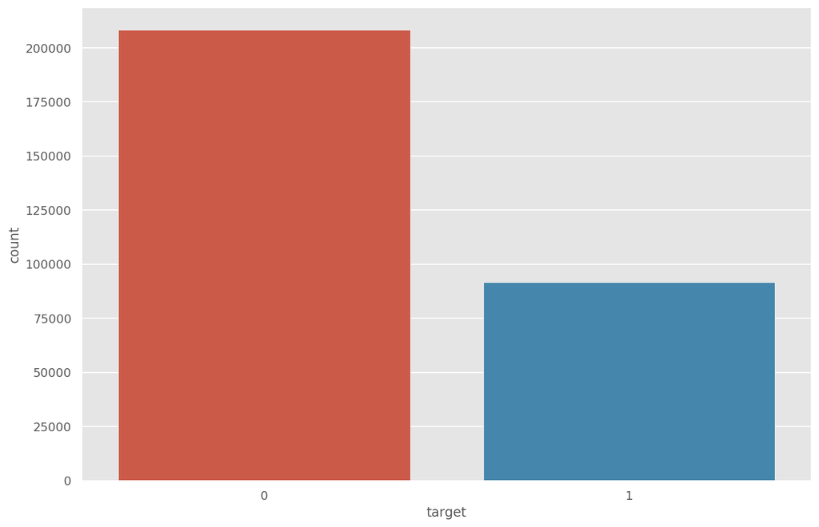

```python
sns.countplot(df['target'])
```

```
Absolute & Relative Frequency of target :
```

|  | Absolute Frequency | Relative Frequency(%) |
| --- | --- | --- |
| 0 | 208236 | 69.41 |
| 1 | 91764 | 30.59 |

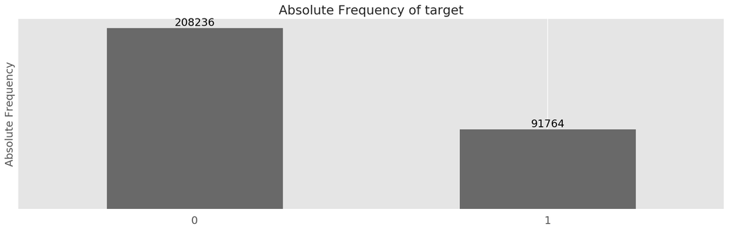

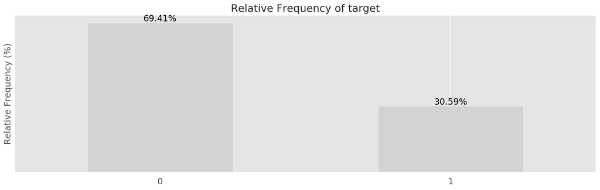

```python
plot_abs_and_rel_counts(df['target'],color=['dimgray','lightgray'])
```

## Binary Features

```python
for c in df.filter(regex='bin').columns:
    print(df[c].value_counts())
```

```
0    261749
1     38251
Name: bin_0, dtype: int64
0    223018
1     76982
Name: bin_1, dtype: int64
0    185033
1    114967
Name: bin_2, dtype: int64
T    153535
F    146465
Name: bin_3, dtype: int64
Y    191633
N    108367
Name: bin_4, dtype: int64
```

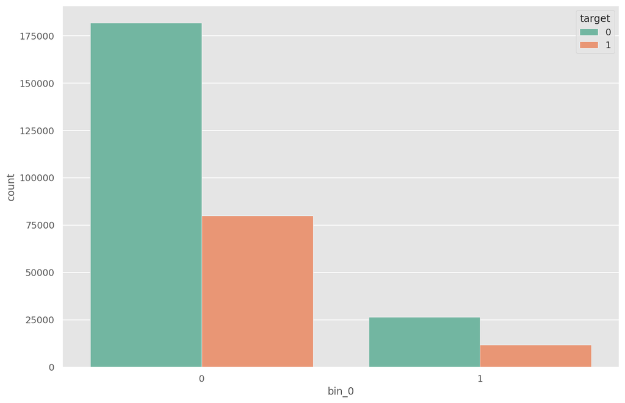

```python
ax = sns.countplot(x='bin_0',hue='target',data=df,palette='Set2')
```

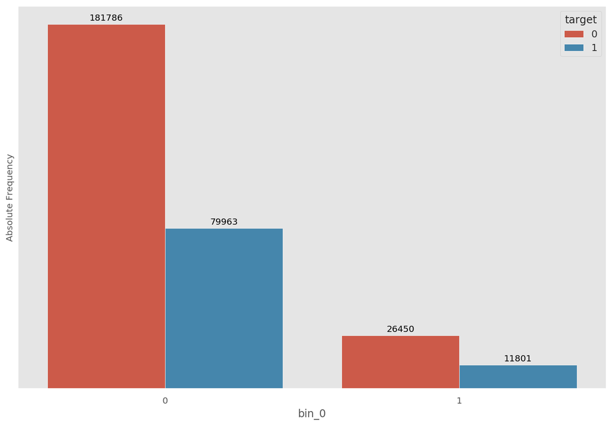

```python
ax = sns.countplot(x='bin_0',hue='target',data=df)
abs_bar_labels_(fontsize=10)
```

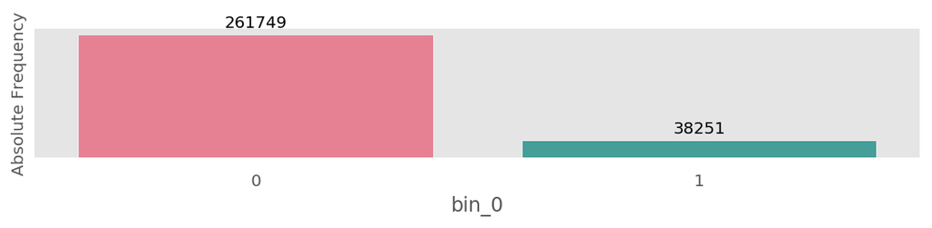

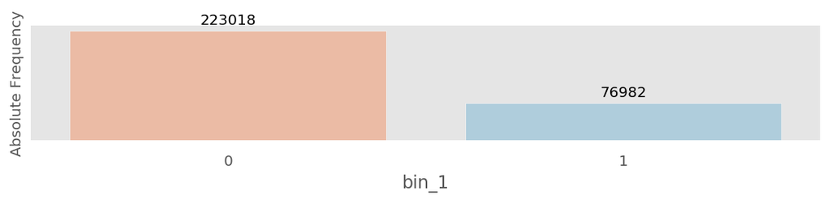

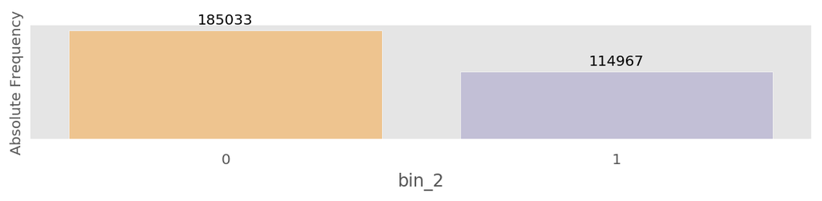

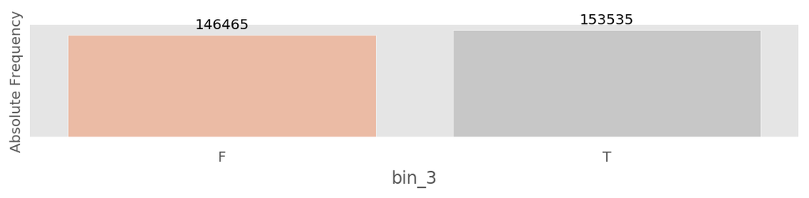

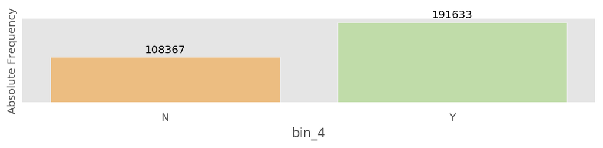

```python
bin_cols = ['bin_0', 'bin_1', 'bin_2', 'bin_3', 'bin_4']
palettes = ['husl','RdBu','PuOr','RdGy','Spectral']
for n, col in enumerate(df[bin_cols]):
    plt.figure(n,figsize=(8,2))
    ax = sns.countplot(x=col, data=df, palette=palettes[n])
    abs_bar_labels_(fontsize=10)
    plt.tight_layout()
```

```python
# the first binary column has very little 1's in it, we may try dropping it.
```

```python
df.drop('bin_0', axis=1,inplace=True)
```

```python
df['bin_3'] = df['bin_3'].map({'T':1, 'F': 0})
df['bin_4'] = df['bin_4'].map({'Y':1, 'N': 0})
```

## Ordinal Features

```python
df.filter(regex='ord').head(2)
```

|  | ord_0 | ord_1 | ord_2 | ord_3 | ord_4 | ord_5 |
| --- | --- | --- | --- | --- | --- | --- |
| 0 | 2 | Grandmaster | Cold | h | D | kr |
| 1 | 1 | Grandmaster | Hot | a | A | bF |

```python
for c in df.filter(regex='ord').columns:
    print(c, df[c].nunique(), df[c].unique())
```

```
ord_0 3 [2 1 3]
ord_1 5 [Grandmaster, Expert, Novice, Contributor, Master]
Categories (5, object): [Grandmaster, Expert, Novice, Contributor, Master]
ord_2 6 [Cold, Hot, Lava Hot, Boiling Hot, Freezing, Warm]
Categories (6, object): [Cold, Hot, Lava Hot, Boiling Hot, Freezing, Warm]
ord_3 15 [h, a, i, j, g, ..., l, n, o, c, m]
Length: 15
Categories (15, object): [h, a, i, j, ..., n, o, c, m]
ord_4 26 [D, A, R, E, P, ..., I, O, C, X, M]
Length: 26
Categories (26, object): [D, A, R, E, ..., O, C, X, M]
ord_5 192 [kr, bF, Jc, kW, qP, ..., Id, pa, ux, kU, Cl]
Length: 192
Categories (192, object): [kr, bF, Jc, kW, ..., pa, ux, kU, Cl]
```

```python
map_ord_1 = {'Novice': 1, 'Contributor': 2,'Expert': 3, 'Master': 4, 'Grandmaster': 5}
map_ord_2 = {'Freezing': 1, 'Cold': 2, 'Warm': 3, 'Hot': 4, 'Boiling Hot': 5, 'Lava Hot': 6}

import string

map_ord_3 = dict(zip(string.ascii_lowercase, range(26)))
map_ord_4 = dict(zip(string.ascii_uppercase, range(26)))

cols_ord = ['ord_1','ord_2','ord_3', 'ord_4']
mappings = [map_ord_1, map_ord_2, map_ord_3, map_ord_4]

for c,mapping in zip(cols_ord, mappings):
    df[c] = df[c].map(mapping)
```

```python
df['ord_5'].unique()
```

```
[kr, bF, Jc, kW, qP, ..., Id, pa, ux, kU, Cl]
Length: 192
Categories (192, object): [kr, bF, Jc, kW, ..., pa, ux, kU, Cl]
```

```python
"""
ordinal 5 column has values combination of lowercase + uppercase
1. sort the string map the index
2. add the index of two letters
3. join the indices of two letters
4. split the column into two parts and then encode separately

""";
```

```python
map_ord_5 = dict(zip(string.ascii_letters, range(26*2)))

df['ord_5a'] = df['ord_5'].str[0].map(map_ord_5)
df['ord_5b'] = df['ord_5'].str[1].map(map_ord_5)
```

```python
df.filter(regex='ord').head()
```

|  | ord_0 | ord_1 | ord_2 | ord_3 | ord_4 | ord_5 | ord_5a | ord_5b |
| --- | --- | --- | --- | --- | --- | --- | --- | --- |
| 0 | 2 | 5 | 2 | 7 | 3 | kr | 10 | 17 |
| 1 | 1 | 5 | 4 | 0 | 0 | bF | 1 | 31 |
| 2 | 1 | 3 | 6 | 7 | 17 | Jc | 35 | 2 |
| 3 | 1 | 5 | 5 | 8 | 3 | kW | 10 | 48 |
| 4 | 1 | 5 | 1 | 0 | 17 | qP | 16 | 41 |

```python
s = sorted(df['ord_5'].unique())
map_ord_5two = dict(zip(s, range(len(s))))

df['ord_5'] = df['ord_5'].map(map_ord_5two)

df.filter(regex='ord').head(2)
```

|  | ord_0 | ord_1 | ord_2 | ord_3 | ord_4 | ord_5 | ord_5a | ord_5b |
| --- | --- | --- | --- | --- | --- | --- | --- | --- |
| 0 | 2 | 5 | 2 | 7 | 3 | 136 | 10 | 17 |
| 1 | 1 | 5 | 4 | 0 | 0 | 93 | 1 | 31 |

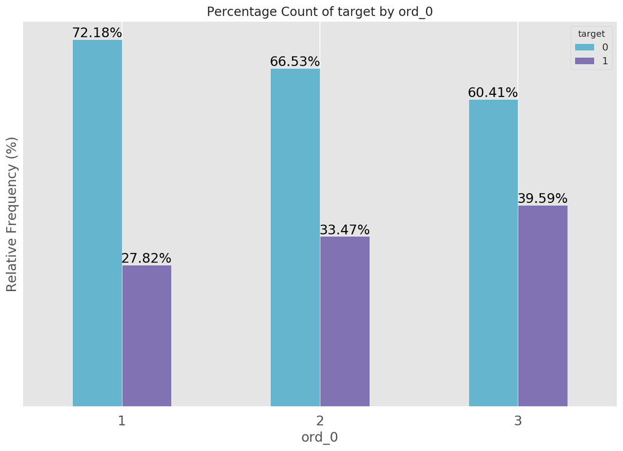

```python
plot_crosstab(df.ord_0, df.target, color = ['c', 'm'])
```

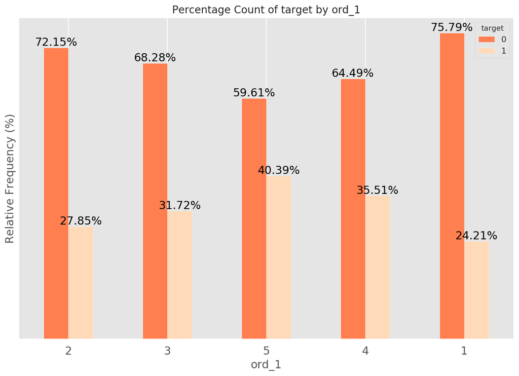

```python
plot_crosstab(df.ord_1, df.target, color = ['coral', 'peachpuff'])
```

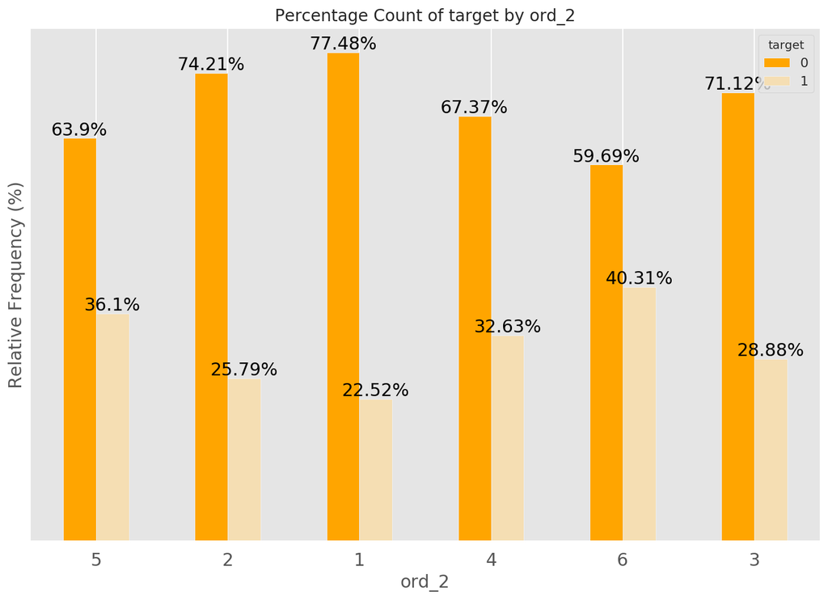

```python
plot_crosstab(df.ord_2, df.target, color = ['orange', 'wheat'])
```

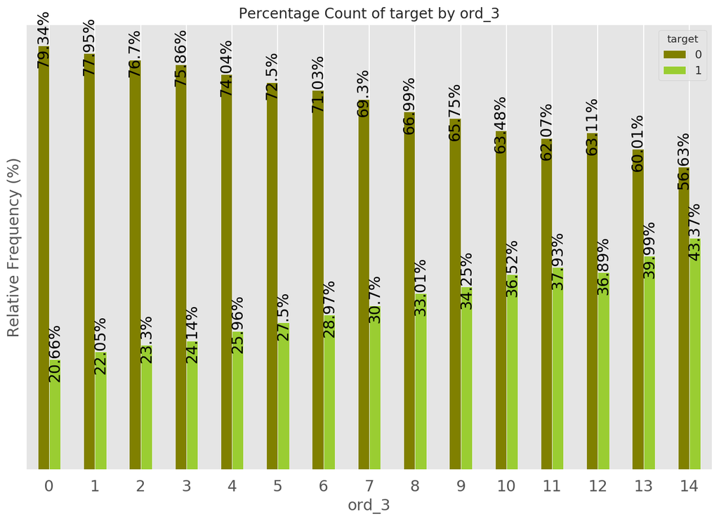

```python
plot_crosstab(df.ord_3, df.target, color = ['olive', 'yellowgreen'],text_rotation=90)
```

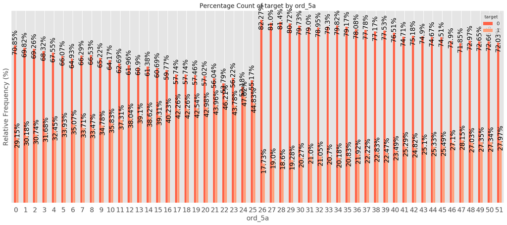

```python
plot_crosstab(df.ord_5a, df.target, color=['tomato', 'lightsalmon'],
              figsize=(20,8),
              text_rotation=90)
```

## Cyclical Features

```python
cols_cyclic =['day','month']

for col in cols_cyclic:
    df[col+'_sin'] = np.sin((2*np.pi* df[col])/max(df[col]))
    df[col+'_cos'] = np.cos((2*np.pi*df[col])/max(df[col]))
    #df.drop(col,axis=1,inplace=True)
```

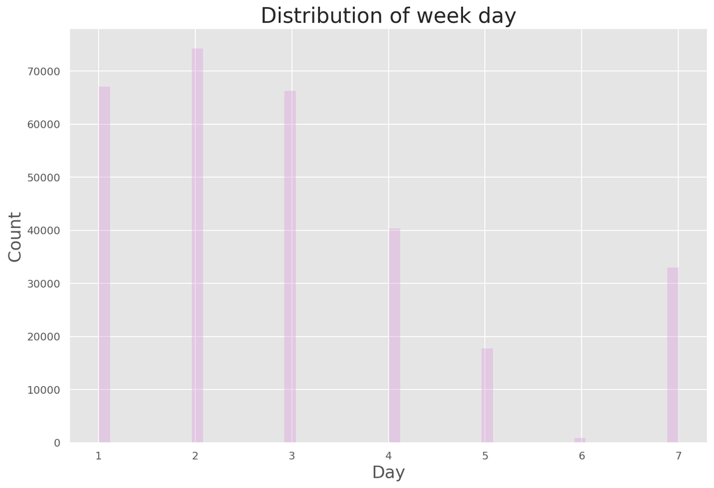

```python
plt.figure(figsize=(12,8))

ax = sns.distplot(df.day, color = 'plum', kde = False)
ax.set_title("Distribution of week day", fontsize=22)
ax.set_xlabel("Day", fontsize=18)
ax.set_ylabel("Count", fontsize=18)

plt.show()
```

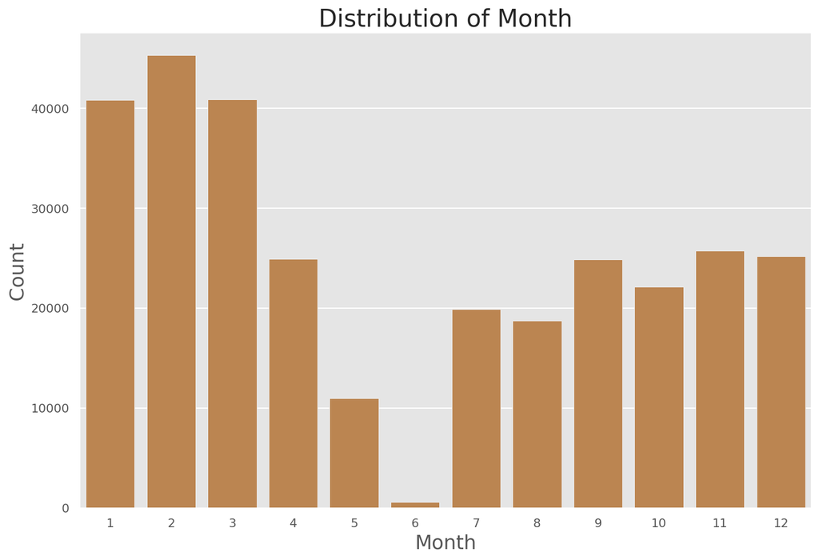

```python
plt.figure(figsize=(12,8))

ax = sns.countplot(df.month, color = 'peru')
ax.set_title("Distribution of Month", fontsize=22)
ax.set_xlabel("Month", fontsize=18)
ax.set_ylabel("Count", fontsize=18)

plt.show()
```

## Nominal Features

```python
cols_nom = df.filter(regex='nom').columns
cols_nom
```

```
Index(['nom_0', 'nom_1', 'nom_2', 'nom_3', 'nom_4', 'nom_5', 'nom_6', 'nom_7',
       'nom_8', 'nom_9'],
      dtype='object')
```

```python
df[cols_nom].nunique().to_frame().rename(columns={0:'nunique'})
```

|  | nunique |
| --- | --- |
| nom_0 | 3 |
| nom_1 | 6 |
| nom_2 | 6 |
| nom_3 | 6 |
| nom_4 | 4 |
| nom_5 | 222 |
| nom_6 | 522 |
| nom_7 | 1220 |
| nom_8 | 2215 |
| nom_9 | 11981 |

```python
# nom_0 to nom_4 have less than 10 features
# nom_5 to nom_9 has high cardinality
# nom_7 to nom_9 have different number of values, we need to make them same.
```

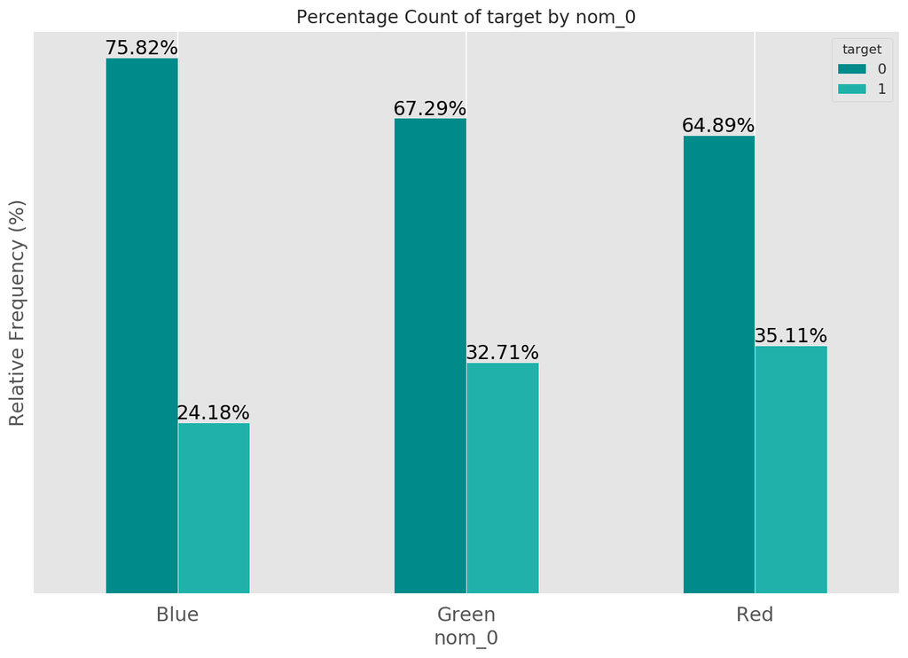

```python
plot_crosstab(df.nom_0, df.target, color = ['darkcyan', 'lightseagreen'])
```

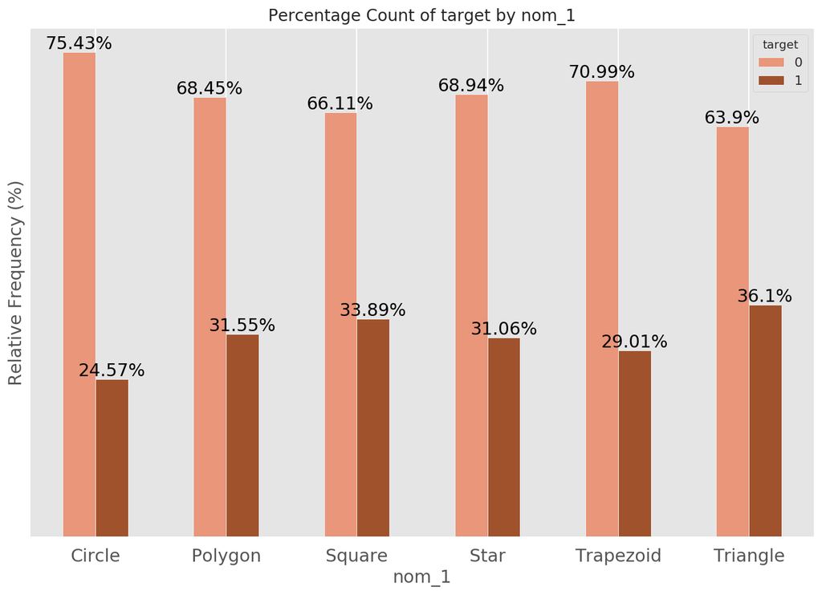

```python
plot_crosstab(df.nom_1, df.target, color = ['darksalmon', 'sienna'])
```

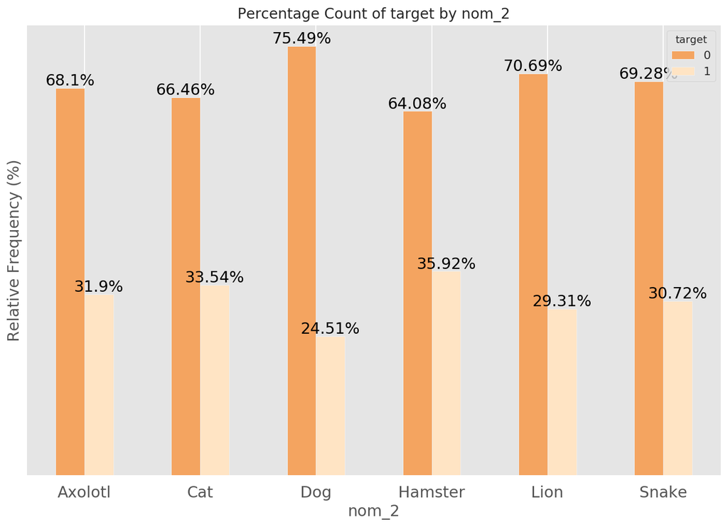

```python
plot_crosstab(df.nom_2, df.target, color = ['sandybrown', 'bisque'])
```

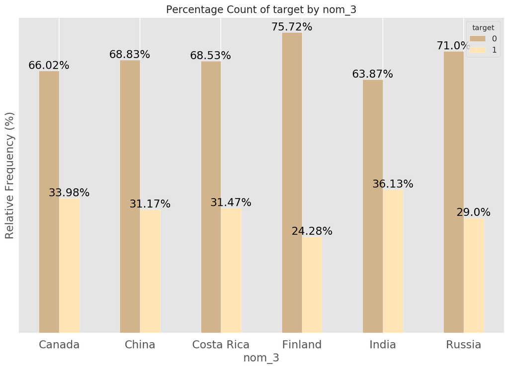

```python
plot_crosstab(df.nom_3, df.target, color = ['tan', 'moccasin'])
```

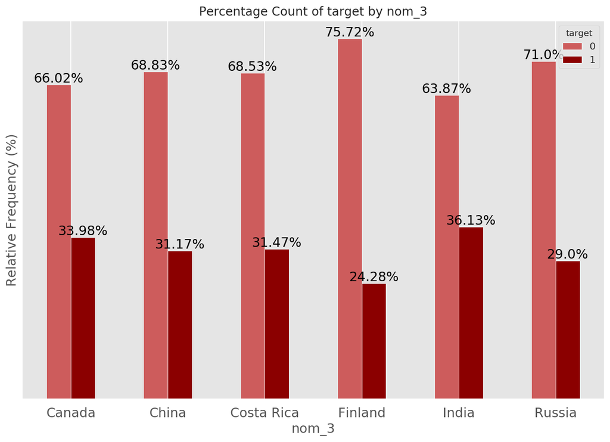

```python
plot_crosstab(df.nom_3, df.target, color = ['indianred', 'darkred'])
```

# Multiple Figure Visualization

Ref: https://www.kaggle.com/artgor/exploring-categorical-encodings

```python
def prepare_plot_dict(df,  col):
    """
    Here we want to show how much higher/lower are the target rates
    for the current column comparing to base values (as described higher)

    At first we calculate base rates,
    then for each category in the column we calculate
    target rate and find difference with the base rates.

    """
    main_count = df['target'].value_counts(normalize=True).sort_index()
    main_count = dict(main_count)
    plot_dict = {}
    for i in df[col].unique():
        val_count = dict(df.loc[df[col] == i, 'target'].value_counts().sort_index())

        for k, v in main_count.items():
            if k in val_count:
                plot_dict[val_count[k]] = ((val_count[k] /
                                            sum(val_count.values())
                                            ) / main_count[k]) * 100 - 100
            else:
                plot_dict[0] = 0

    return plot_dict


def make_count_plot(df, x, hue='target', title=''):
    """
    Plotting countplot with correct annotations.
    """
    g = sns.countplot(x=x, data=df, hue=hue);
    plt.title(f'Target {title}');
    ax = g.axes

    plot_dict = prepare_plot_dict(df, x)

    for p in ax.patches:
        h = p.get_height() if str(p.get_height()) != 'nan' else 0

        text = f"{plot_dict[h]:.0f}%" if plot_dict[h] < 0 \
        else f"+{plot_dict[h]:.0f}%"

        ax.annotate(text, (p.get_x() + p.get_width() / 2., h),
              ha='center', va='center', fontsize=11,
              color='green' if plot_dict[h] > 0 else 'red',
              rotation=0, xytext=(0, 10),
              textcoords='offset points')


def plot_two_graphs(df_train, df_train_test, col= '', top_n = None):
    """
    Plotting four graphs:
    - target by variable;
    - counts of categories in the variable in train and test;
    """
    df_train1 = df_train.copy()
    df_all    = df_train_test.copy()
    if top_n:
        top_cats  = list(df_train1[col].value_counts()[:5].index)
        df_train1 = df_train1.loc[df_train1[col].isin(top_cats)]
        df_all    = df_all.loc[df_all[col].isin(top_cats)]

    plt.figure(figsize=(20, 12));
    plt.subplot(2, 2, 1)
    make_count_plot(df=df_train1, x=col, title=f'and {col}')

    plt.subplot(2, 2, 2)
    sns.countplot(x='train_test_type', data=df_all, hue=col);
    plt.title(f'Count of samples in {col} in train and test data');
```

```python
ifile_train = 'https://github.com/bhishanpdl/Project_Categorical_Feature_Encoding/blob/master/data/raw/train.csv?raw=true'
ifile_test = 'https://github.com/bhishanpdl/Project_Categorical_Feature_Encoding/blob/master/data/raw/test.csv?raw=true'

df_train = pd.read_csv(ifile_train)
df_test = pd.read_csv(ifile_test)

df_train.drop('id', axis=1, inplace=True)
df_test.drop('id',axis=1,inplace=True)
```

```python
df_train = df_train.sample(frac=0.1)
df_test = df_test.sample(frac=0.1)

df_train['train_test_type'] = 'train'
df_test['train_test_type'] = 'test'

df_train_test = pd.concat([df_train, df_test],sort=False)

print(df_train_test.shape)

df_train_test.head(2).append(df_train_test.tail(2))
```

```
(50000, 25)
```

|  | bin_0 | bin_1 | bin_2 | bin_3 | bin_4 | nom_0 | nom_1 | nom_2 | nom_3 | nom_4 | nom_5 | nom_6 | nom_7 | nom_8 | nom_9 | ord_0 | ord_1 | ord_2 | ord_3 | ord_4 | ord_5 | day | month | target | train_test_type |
| --- | --- | --- | --- | --- | --- | --- | --- | --- | --- | --- | --- | --- | --- | --- | --- | --- | --- | --- | --- | --- | --- | --- | --- | --- | --- |
| 18828 | 0 | 1 | 0 | F | N | Blue | Trapezoid | Cat | Costa Rica | Oboe | 5b1a9f841 | 4daee3baf | 8145adbe4 | 801927581 | 77bd4118a | 1 | Novice | Warm | h | U | nh | 2 | 2 | 0.0 | train |
| 128595 | 0 | 0 | 1 | T | N | Green | Trapezoid | Snake | China | Bassoon | 416a8f3ab | 628f3170f | 1726041fb | 606ac930b | 178e5ecc0 | 1 | Grandmaster | Hot | a | K | RP | 4 | 12 | 0.0 | train |
| 126688 | 0 | 0 | 0 | F | Y | Green | Trapezoid | Lion | Costa Rica | Oboe | 19db35594 | 9a16c7c8f | 04a6f404e | 60f23b85b | 8e9c6dd63 | 1 | Contributor | Boiling Hot | j | S | MV | 3 | 5 | nan | test |
| 17198 | 0 | 1 | 0 | T | Y | Green | Trapezoid | Lion | Canada | Piano | 83b38aa6b | 8c9d16cc3 | 51bfb741c | 5127124be | b68dfbb05 | 2 | Novice | Cold | h | G | Qb | 4 | 2 | nan | test |

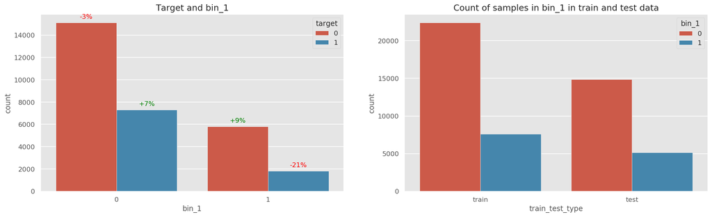

```python
plot_two_graphs(df_train,df_train_test,col='bin_1')
```